# Hyperspectral wavelength and Vegetation Index selection R-Code

Thomas Wabnig

21 05 2026

## 1. MAMMALS and PENGUINS NDVI

As an example we use the dataset “mammals” to show how NDVI can in principle be used as “scales” to weigh, in this case the total bodymass in comparison to the mass of the brain.

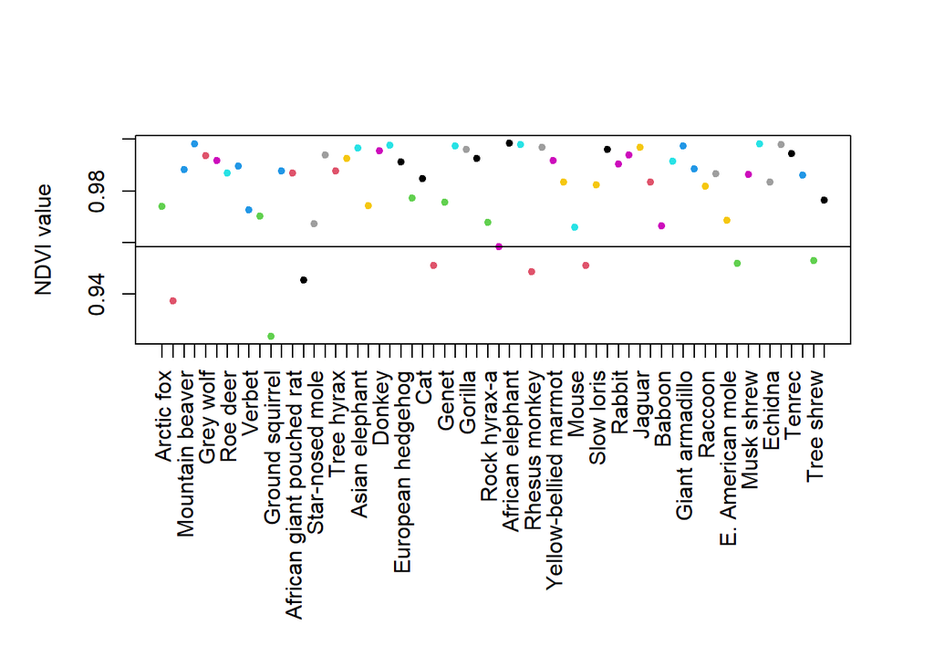

```r
if(!require(MASS)){
install.packages("MASS")
suppressPackageStartupMessages(library(MASS))
}

if(!require(tidyverse)){
install.packages("tidyverse")
suppressPackageStartupMessages(library(tidyverse))
}

mammals <- as.data.frame(mammals)
mammals$body <- mammals$body*1000
mammals <- mutate(mammals, ndvi=(((body-brain)/(body+brain))))

par(oma=c(7,1,1,1))
plot(mammals$ndvi, col=as.factor(row.names(mammals)), pch=20,
main="", xaxt='n', xlab="", ylab="NDVI value")
axis(1, at=1:nrow(mammals), labels=row.names(mammals),las=2)
query <- which(row.names(mammals)=="Human")
abline(h=mammals[query,][3])
```

We see that when compared to its total bodymass, a ground squirrel allocates the most mass to its brain. It is important to understand: 1. The order in which we plug in the values is arbitrary. 2. Negative NDVI-values are not indicative of a “negative weight” (Note: In this special case, we do not have negative values).

```r
if(!require(palmerpenguins)){
install.packages("palmerpenguins")
suppressPackageStartupMessages(library(palmerpenguins))
}

if(!require(tidyverse)){
install.packages("tidyverse")
suppressPackageStartupMessages(library(tidyverse))
}

penguins <- as.data.frame(penguins)
penguins <- na.omit(penguins)
pndvi <- penguins %>% group_by(species, sex) %>% summarize(mean(body_mass_g))

(pndvi[1,3]-pndvi[2,3])/(pndvi[1,3]+pndvi[2,3])
```

```
##   mean(body_mass_g)
## 1        -0.0910183
```

```r
(pndvi[3,3]-pndvi[4,3])/(pndvi[3,3]+pndvi[4,3])
```

```
##   mean(body_mass_g)
## 1       -0.05515068
```

```r
(pndvi[5,3]-pndvi[6,3])/(pndvi[5,3]+pndvi[6,3])
```

```
##   mean(body_mass_g)
## 1       -0.07920592
```

```r
# Values are the NDVI values
```

In this case we also have negative values. The formula would be: (female bodyweight - male bodyweight) / (female bodyweight + male bodyweight). We conclude that on average male penguins are heavier compared to female penguins.

## 2. Probability Mass Function for 1 die, and for 2 dice:

A Probability Mass Function shows us every output we can in principle have once. For 1 die we can get: 1,2,3,4,5,6 and each with a equal probability. The histogram shows a uniform distribution.

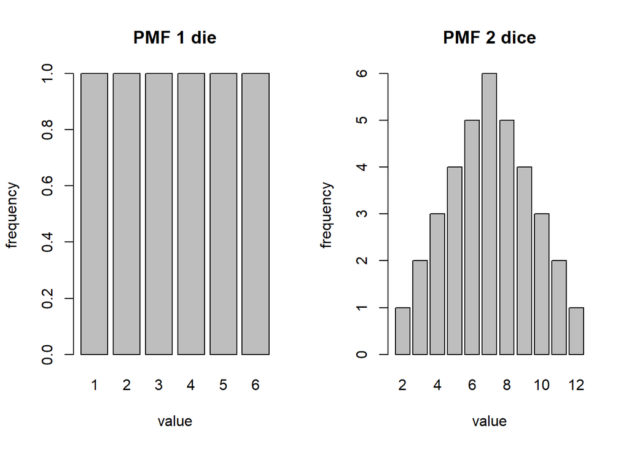

```r
if(!require(tidyverse)){
install.packages("tidyverse")
suppressPackageStartupMessages(library(tidyverse))
}

par(mfrow=c(1,2))

num <- c(1:6)
barplot(table(num), main="PMF 1 die", ylab="frequency", xlab="value")

nums <- expand.grid(num,num)
nums <- mutate(nums, sums=Var1+Var2)
barplot(table(nums$sums), main="PMF 2 dice", ylab="frequency", xlab="value")
```

In the case of 1 die, we have a uniform distribution; with 2 dice the distribution is non-uniform. We will now simulate 10.000 dice rolls 3 times and see that the overall shape is similar to the theoretical Probability Mass Function (PMF). The value 7 is the most frequent one, and roughly 6 times more likely/frequent than a 2, or 12. We assume this to be a consequence of the law of large numbers, whereby empirical distributions converge to their theoretical probabilities if the sample size increases.

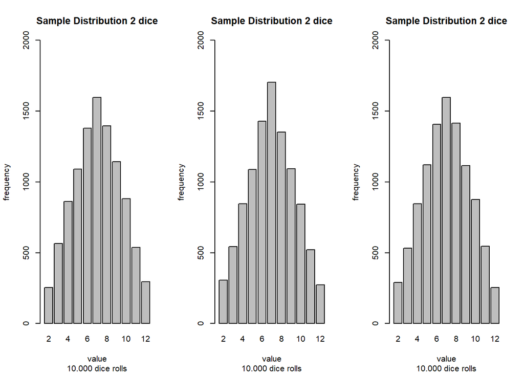

```r
two.dice <- function(){
  dice <- sample(1:6, size = 2, replace = TRUE)
  return(sum(dice))
}
par(mfrow=c(1,3))
res <- replicate(n = 10000, expr = two.dice())
barplot(table(res), ylab="frequency", xlab="value", sub="10.000 dice rolls",
main="Sample Distribution 2 dice", ylim=c(0,2000))

res <- replicate(n = 10000, expr = two.dice())
barplot(table(res), ylab="frequency", xlab="value", sub="10.000 dice rolls",
main="Sample Distribution 2 dice", ylim=c(0,2000))

res <- replicate(n = 10000, expr = two.dice())
barplot(table(res), ylab="frequency", xlab="value", sub="10.000 dice rolls",
main="Sample Distribution 2 dice", ylim=c(0,2000))
```

## 3. Probability Mass Function for the NDVI:

We can do the same thing but instead of adding the 2 values up, we plug the random values in the function (a-b)/(a+b), and get a PMF that looks similar to the Thomae Function:

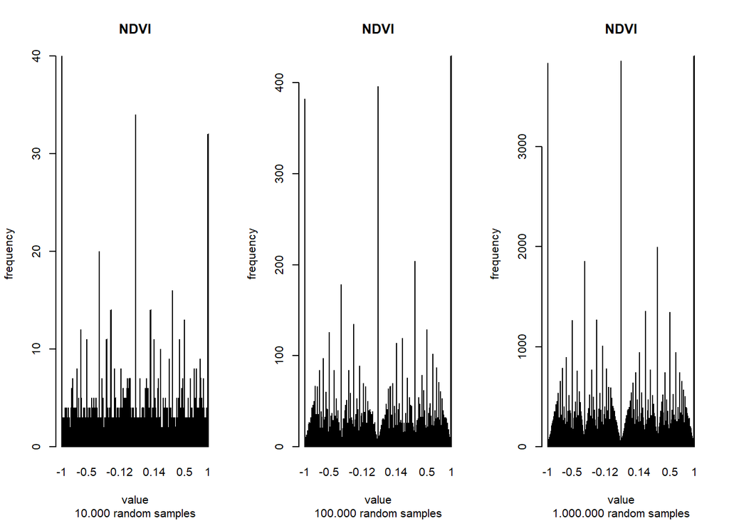

```r
two.dice <- function(){
  dice <- sample(0:255, size = 2, replace = TRUE)
  return(((dice[1]-dice[2])/(dice[1]+dice[2])))
}

par(mfrow=c(1,3))

res <- replicate(n = 10000, expr = two.dice())
barplot(table(res), ylab="frequency", xlab="value", sub="10.000 random samples",
main="NDVI")

res <- replicate(n = 100000, expr = two.dice())
barplot(table(res), ylab="frequency", xlab="value", sub="100.000 random samples",
main="NDVI")

res <- replicate(n = 1000000, expr = two.dice())
barplot(table(res), ylab="frequency", xlab="value", sub="1.000.000 random samples",
main="NDVI")
```

Although 1.000.000 values might seem large, we have to keep in mind that a 24 Megapixel digital camera has 24.000.000 pixels (6000 x 4000). In this case we would consider each combination of an infrared and red combination 1 experiment, trial, or dice throw. Note: This assumption can be challenged, as those 2 wavelengths might not be independent or covary.

## 1e. Examples for other PMFs

As we are mainly interested in the PMF for the NDVI-function, here are some other examples of PMFs for some Vegetation Indices:

```r
if(!require(tidyverse)){
install.packages("tidyverse")
library(tidyverse)
}

NORMALIZE <- function(x) {(x - min(x))/(max(x)- min(x))}

SR <- function(x,y) {(x/y)}
NDVI <- function(x,y) {((x-y)/(x+y))}
RDVI <- function(x,y) {((x-y)/(sqrt(x+y)))}
ONLI <- function(a,b) {((1+0.05)*(((0.6*(a^2)))- b))/((0.6*a)+b+0.05)}

a <- c(0:255)
b <- expand.grid(a,a)
b <- mutate(b, sr=SR(Var1,Var2), ndvi=NDVI(Var1,Var2), rdvi=RDVI(Var1,Var2),
onli=ONLI(Var1,Var2))
b <- mutate(b, kndvi=tanh(ndvi^2))
b <- mutate(b, urfi=((2*ndvi)/(1+abs(ndvi))))
b$urfi <- round(b$urfi,2)


b <- mutate(b, normsum=NORMALIZE(Var1+Var2))
vec <- ifelse(b$ndvi<0, -1, 1)
b <- mutate(b, vibe=normsum*vec)

p <- b
p <- subset(b, ndvi>0)

par(mfrow=c(3,3))
barplot(table(b$sr), main="SR", ylab="frequency", xlab="SR value", sub="8-bit,
D=(0,1,2,...255)")
barplot(table(b$ndvi), main="NDVI", ylab="frequency", xlab="NDVI value", sub="8-bit,
D=(0,1,2,...255)")
barplot(table(b$rdvi), main="RDVI", ylab="frequency", xlab="RDVI value", sub="8-bit,
D=(0,1,2,...255)")
barplot(table(b$onli), main="ONLI", ylab="frequency", xlab="ONLI value", sub="8-bit,
D=(0,1,2,...255)")
barplot(table(b$kndvi), main="kNDVI", ylab="frequency", xlab="kNDVI value", sub="8-bit,
D=(0,1,2,...255)")
barplot(table(b$urfi), main="URFI", ylab="frequency", xlab="URFI value", sub="8-bit,
D=(0,1,2,...255)")
barplot(table(b$vibe), main="VIBE", ylab="frequency", xlab="VIBE value", sub="8-bit,
D=(0,1,2,...255)")
barplot(table(p$vibe), main="VIBE (only positive values)", ylab="frequency", xlab="VIBE value",
sub="8-bit, D=(0,1,2,...255)")

max(b$vibe[is.finite(b$vibe)])
```

```
## [1] 1
```

```r
min(b$vibe[is.finite(b$vibe)])
```

```
## [1] -0.9980392
```

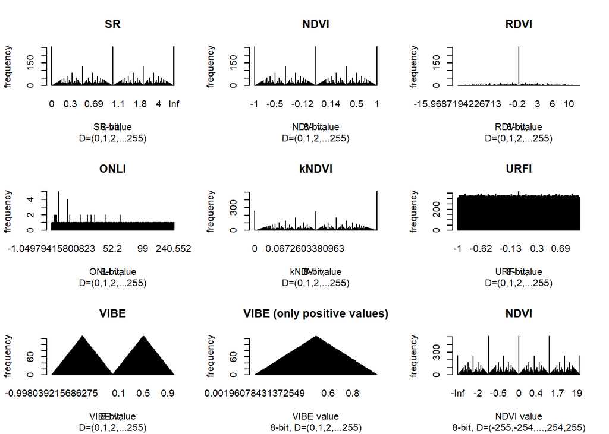

```r
a <- c(-255:255)
b <- expand.grid(a,a)
b <- mutate(b, sr=SR(Var1,Var2), ndvi=NDVI(Var1,Var2), rdvi=RDVI(Var1,Var2),
onli=ONLI(Var1,Var2))
b <- mutate(b, kndvi=tanh(ndvi^2))
b <- mutate(b, urfi=((2*ndvi)/(1+abs(ndvi))))
b$urfi <- round(b$urfi,2)

barplot(table(b$ndvi), main="NDVI", ylab="frequency", xlab="NDVI value",
sub="8-bit, D=(-255,-254,...,254,255)")
```

## 4. NDVI for positive and negative values

Example:

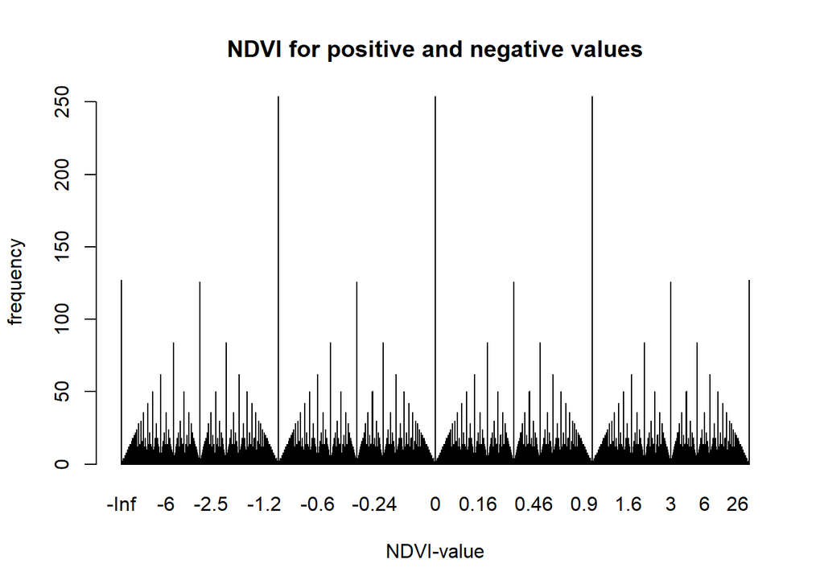

```r
if(!require(tidyverse)){
install.packages("tidyverse")
suppressPackageStartupMessages(library(tidyverse))
}

if(!require(psych)){
install.packages("psych")
suppressPackageStartupMessages(library(psych))
}

INF.OMIT <- function(x) {x[!is.infinite(rowSums(x)),]}
vec <- c(-127:127)
comb <- expand.grid(vec,vec)
comb <- mutate(comb, ndvi=(((Var1-Var2)/(Var1+Var2))))
x11()
barplot(table(comb$ndvi), main="NDVI for positive and negative values",
ylab="frequency", xlab="NDVI-value")
```

```r
comb <- INF.OMIT(comb)
res <- as.numeric(unlist(names(table(comb$ndvi))))
describe(res)
```

```
##    vars     n mean    sd median trimmed  mad  min max range skew kurtosis   se
## X1    1 19831    0 19.23      0       0 1.48 -253 253   506    0    78.35 0.14
```

We can see that NDVI ranges between +/-1 if, and only if both inputs are positive.

## 5. Transform to approximately uniform distribution in some interval

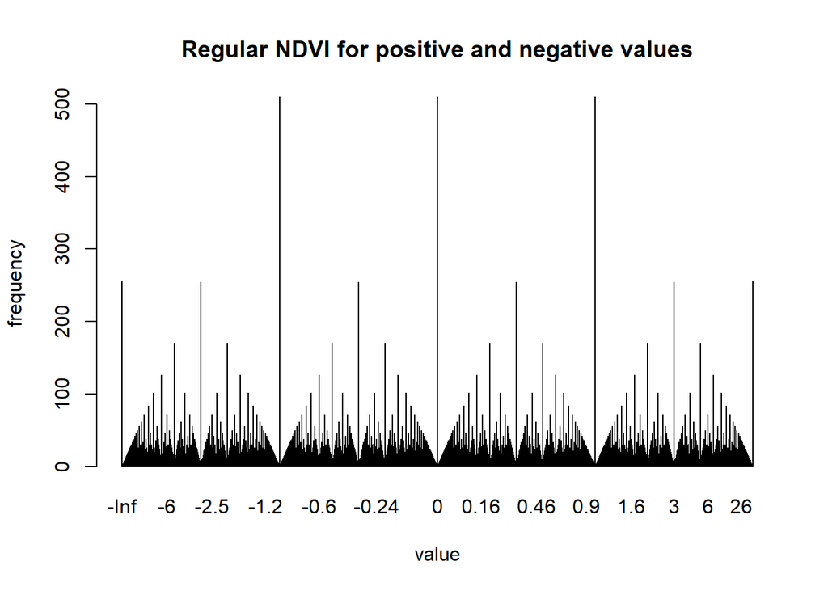

```r
if(!require(tidyverse)){
install.packages("tidyverse")
library(tidyverse)
}

if(!require(psych)){
install.packages("psych")
library(psych)
}

vec <- c(-255:255)
co <- expand.grid(vec,vec)
co <- mutate(co, n=(((Var1-Var2)/(Var1+Var2))))
co <- mutate(co, urfi4=((4*n)/(1+abs(n))))
co <- mutate(co, urfi2=((2*n)/(1+abs(n))))
co$urfi2r <- round(co$urfi2, 2)
co$urfi4r <- round(co$urfi4, 2)


barplot(table(co$n), xlab="value", ylab="frequency",
main="Regular NDVI for positive and negative values")
```

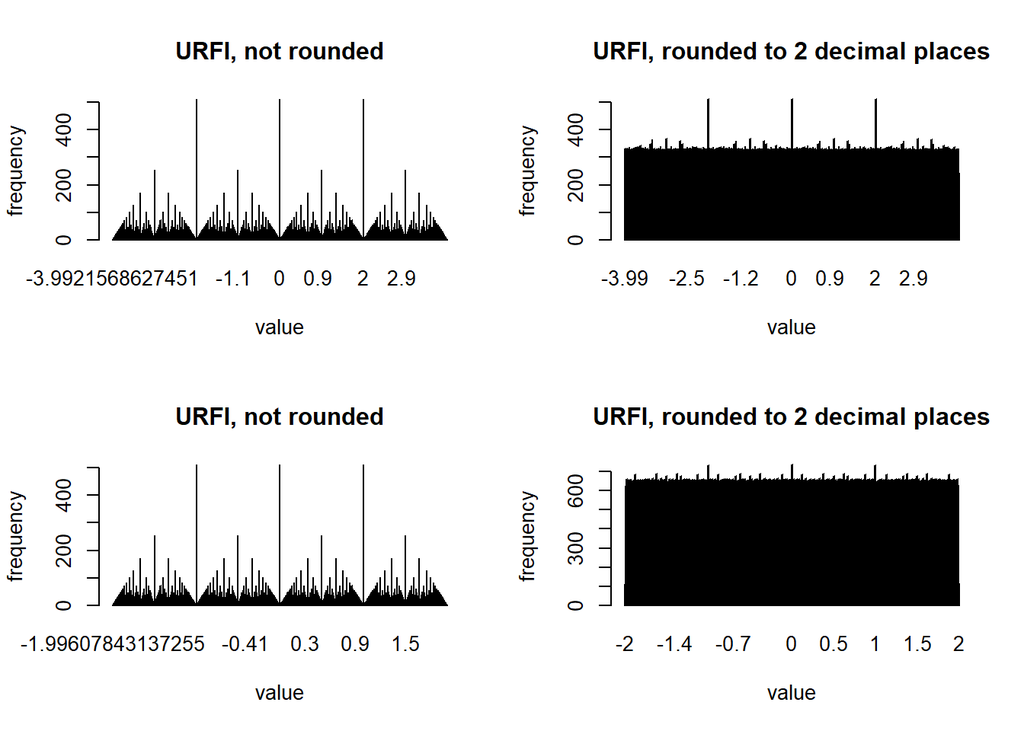

```r
par(mfrow=c(2,2))
barplot(table(co$urfi4), xlab="value", ylab="frequency", main="URFI, not rounded")
barplot(table(co$urfi4r), main="URFI, rounded to 2 decimal places", xlab="value", ylab="frequency")
barplot(table(co$urfi2), xlab="value", ylab="frequency", main="URFI, not rounded")
barplot(table(co$urfi2r), main="URFI, rounded to 2 decimal places", xlab="value", ylab="frequency")
```

```r
describe(co$urfi2r)
```

```
##    vars      n mean   sd median trimmed  mad min max range skew kurtosis se
## X1    1 260610    0 1.15      0       0 1.48  -2   2     4    0     -1.2  0
```

```r
describe(co$urfi2r)
```

```
##    vars      n mean   sd median trimmed  mad min max range skew kurtosis se
## X1    1 260610    0 1.15      0       0 1.48  -2   2     4    0     -1.2  0
```

The modified NDVI (i.e. URFI) is now more comparable to a single die.

## 6. A practical example:

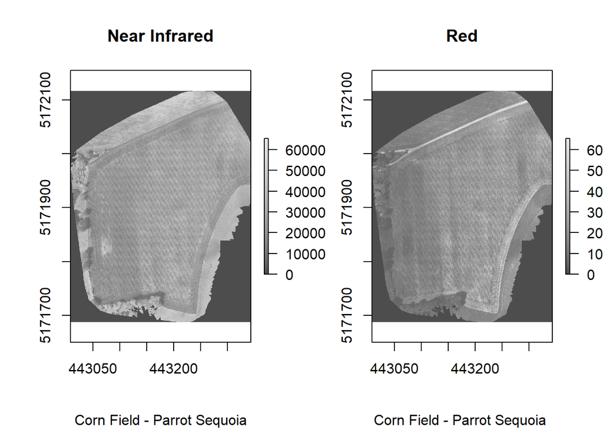

```r
setwd("D:/")


NORMALIZE <- function(x) {
  min <- raster::minValue(x)
  max <- raster::maxValue(x)
  return((x - min) / (max - min))
}

NORMALIZEd <- function(x) {(x - min(x))/(max(x)- min(x))}

SIGN <- function(ndvi) {sign <- ifelse(raster::values(ndvi)< 0, -1, 1)}


if(!require(raster)){
    install.packages("raster")
    library(raster)
}
if(!require(rasterImage)){
    install.packages("rasterImage")
    library(rasterImage)
}
if(!require(rgdal)){
    install.packages("rgdal")
    library(rgdal)
}
if(!require(tidyverse)){
    install.packages("tidyverse")
    library(tidyverse)
}

red <- raster(x ="tilered.tif")
nir <- raster(x ="tilenir.tif")

par(mfrow=c(1,2))
plot(nir, main="Near Infrared", sub="Corn Field - Parrot Sequoia",
col = gray.colors(200))
plot(red, main="Red", sub="Corn Field - Parrot Sequoia ",
col = gray.colors(200))
```

```r
par(mfrow=c(1,1))
ndvi <- (nir-red)/(nir+red)
   ndvi_df <- as.data.frame(values(ndvi))
   ndvi_df <- na.omit(ndvi_df)
   tab <- table(ndvi_df)
describe(as.numeric(names(tab)))
```

```
##    vars        n mean   sd median trimmed mad min max range  skew kurtosis se
## X1    1 33399790 0.17 0.25    0.2    0.18 0.3  -1   1     2 -0.26    -0.88  0
```

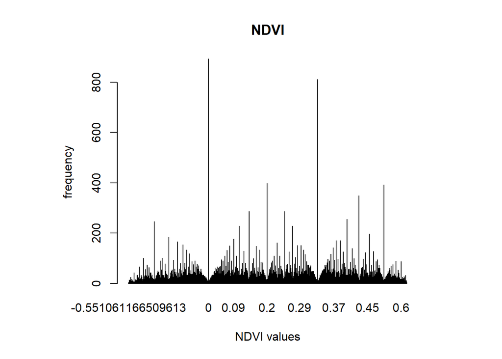

```r
untab <- as.numeric(unlist(subset(ndvi_df$values, ndvi_df$values >(-1) & ndvi_df$values<1)))
barplot(table(untab), main="NDVI", xlab="NDVI values", ylab="frequency")
```

```r
sum_nir_red <- nir+red
norm_sum_nir_red <- NORMALIZE(sum_nir_red)
summary(norm_sum_nir_red)
```

```
##             layer
## Min.    0.0000000
## 1st Qu. 0.1613061
## Median  0.3487125
## 3rd Qu. 0.4493212
## Max.    1.0000000
## NA's    0.0000000
```

```r
sign <- SIGN(ndvi)
summary(sign)
```

[output not shown]

```r
vibe <- norm_sum_nir_red*sign
summary(vibe)
```

```
##                 layer
## Min.    -1.000000e+00
## 1st Qu. -2.806254e-01
## Median   3.281301e-01
## 3rd Qu.  4.367879e-01
## Max.     9.193714e-01
## NA's     1.100784e+07
```

```r
urfi <- (2*ndvi)/(1+abs(ndvi))
urfi <- round(urfi,2)

par(mfrow=c(3,3))
plot(ndvi, main="NDVI")
plot(urfi, main="URFI")
plot(vibe, main="VIBE")

hist(ndvi, xlab = "NDVI Value", ylab = "Frequency", col = "green", sub="Normalized Difference Vegetation Index", main="")
hist(urfi, xlab = "URFI Value", ylab = "Frequency", col = "red", sub="Uniform Relative Frequency Index", main="")
hist(vibe, xlab = "VIBE Value", ylab = "Frequency", col = "blue", sub="Vegetation Index for Biomass Estimation", main="")


vec <- c(0:255)
combinations <- expand.grid(vec,vec)
NDVI <- function(x,y) {((x-y)/(x+y))}
URFI <- function(ndvi) {(2*ndvi)/(1+abs(ndvi))}
combinations <- mutate(combinations, ndvi=NDVI(Var1,Var2))
urfi <- URFI(combinations$ndvi)
urfi <- round(urfi,2)
combinations <- mutate(combinations, normsum=NORMALIZEd(Var1+Var2))
vec <- ifelse(combinations$ndvi<0, -1, 1)
combinations <- mutate(combinations, VIBE=normsum*vec)

length(which(combinations$VIBE>(1)))
```

```
## [1] 0
```

```r
length(which(combinations$VIBE<(-1)))
```

```
## [1] 0
```

```r
length(which(combinations$VIBE<(1)))
```

```
## [1] 65534
```

```r
length(which(combinations$VIBE>(-1)))
```

```
## [1] 65535
```

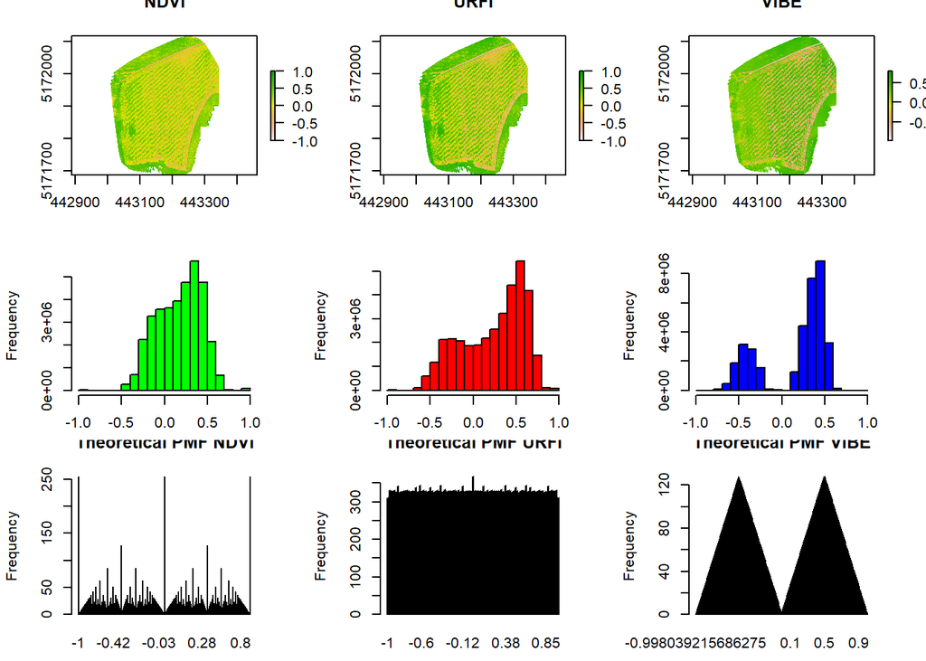

```r
barplot(table(combinations$ndvi), main="Theoretical PMF NDVI", xlab="NDVI Value", ylab="Frequency")
barplot(table(urfi), main="Theoretical PMF URFI", xlab="URFI Value", ylab="Frequency")
barplot(table(combinations$VIBE), main="Theoretical PMF VIBE", xlab="VIBE Value", ylab="Frequency")
```

REFERENCES:

Camps-Valls G, Campos-Taberner M, Moreno-Martínez Á, Walther S, Duveiller G, Cescatti A, Mahecha MD, Muñoz-Marí J, García-Haro FJ, Guanter L, Jung M, Gamon JA, Reichstein M, Running SW. A unified vegetation index for quantifying the terrestrial biosphere. Sci Adv. 2021 Feb 26;7(9):eabc7447. doi: 10.1126/sciadv.abc7447. PMID: 33637524; PMCID: PMC7909876.

Feng, W., Wu, Y., He, L. et al. An optimized non-linear vegetation index for estimating leaf area index in winter wheat. Precision Agric 20, 1157–1176 (2019). https://doi.org/10.1007/s11119-019-09648-8

Jordan, C.F. (1969) Derivation of Leaf Area Index from Quality of Light on the Forest Floor. Ecology, 50, 663-666. http://dx.doi.org/10.2307/1936256

Kaiblinger & Wabnig (2019): Modified NDVI formula for uniformly distributed values. Unpublished Mansucript.

Perry, C. Jr., and L.F. Lautenschlager, 1984. Functional Equivalence of Spectral Vegetation Indices, Remote Sensing of Environment, 14(1-3): 169-182.

Rouse J.W., Haas R.H., Schell J.A., Deering D.W. (1973): Monitoring vegetation systems in the Great Plains with ERTS. In3rd ERTS Symposium, NASA SP-351 I, pp. 309–317

Roujean, J. L., & Bréon, F. M. (1995). Estimating PAR absorbed by vegetation from bidirectional reflectance measurements. Remote Sensing of Environment, 51(3), 375-384.